# IODS course project

## Exercise 3: regression analysis

```r
fit<-lm(points~attitude+age+deep,data=student_2014)
fit
```

```
##
## Call:
## lm(formula = points ~ attitude + age + deep, data = student_2014)
##
## Coefficients:
## (Intercept)     attitude          age         deep
##    15.60773      3.59413     -0.07716     -0.60275
```

```r
summary(fit)
```

```
##
## Call:
## lm(formula = points ~ attitude + age + deep, data = student_2014)
##
## Residuals:
##     Min      1Q  Median      3Q     Max
## -17.206  -3.430   0.204   3.979  10.950
##
## Coefficients:
##             Estimate Std. Error t value Pr(>|t|)
## (Intercept) 15.60773    3.38966   4.605 8.32e-06 ***
## attitude     3.59413    0.56959   6.310 2.56e-09 ***
## age         -0.07716    0.05322  -1.450    0.149
## deep        -0.60275    0.75031  -0.803    0.423
## ---
## Signif. codes:  0 '***' 0.001 '**' 0.01 '*' 0.05 '.' 0.1 ' ' 1
##
## Residual standard error: 5.307 on 162 degrees of freedom
## Multiple R-squared:  0.2043, Adjusted R-squared:  0.1896
## F-statistic: 13.87 on 3 and 162 DF,  p-value: 4.305e-08
```

The only variable that has a statistically significant relation with exam points is the attitude-variable. Age and deep approach do not have a statistically significant relationship with exam points.

```r
fit2<-lm(points~attitude, data=student_2014)
fit2
```

```
##
## Call:
## lm(formula = points ~ attitude, data = student_2014)
##
## Coefficients:
## (Intercept)     attitude
##      11.637        3.525
```

```r
summary(fit2)
```

```
##
## Call:
## lm(formula = points ~ attitude, data = student_2014)
##
## Residuals:
##      Min       1Q   Median       3Q      Max
## -16.9763  -3.2119   0.4339   4.1534  10.6645
##
## Coefficients:
##             Estimate Std. Error t value Pr(>|t|)
## (Intercept)  11.6372     1.8303   6.358 1.95e-09 ***
## attitude      3.5255     0.5674   6.214 4.12e-09 ***
## ---
## Signif. codes:  0 '***' 0.001 '**' 0.01 '*' 0.05 '.' 0.1 ' ' 1
##
## Residual standard error: 5.32 on 164 degrees of freedom
## Multiple R-squared:  0.1906, Adjusted R-squared:  0.1856
## F-statistic: 38.61 on 1 and 164 DF,  p-value: 4.119e-09
```

## Exercise 4: interpreting model parameters

The only explanatory varialbe, attitude, is a significant predictor of exam points (p -value close to 0.) When attitude increases one point, exam points increases on average 3.5255 points. Multiple R-square is 0.1906, meaning that the attitude variable can explain about one fifth of the variance in exam points, which is fairly good.

## Exercise 5: assumptions of regression model

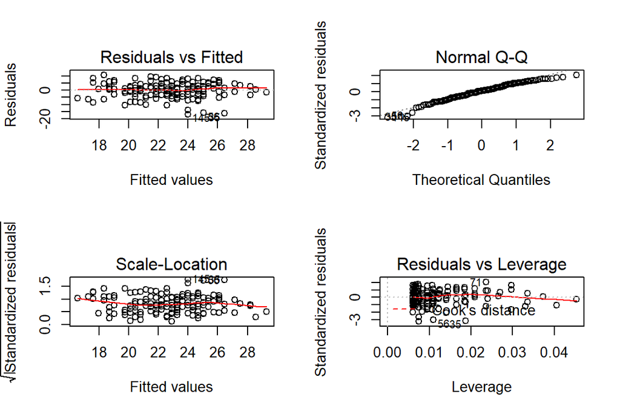

```r
par(mfrow=c(2,2))
plot(fit2)
```

When looking at fitted values vs. residuals one can see whether there are non-linear patterns. In this case there are not. When looking at normal Q-Q -plot we can see that whether residuals are normally distributed. In this case they are. Scale location -plot shows that residuals are also spread equally along the ranges of predictors. Residuals vs. leverage -plot shows whether there are influential cases against the regression line. In this case there are not.

So, we can say that regression model is a suitable method with this data.

# Chapter 3: Logistic regression

## Exercise 2: The dataset of this exercise

```r
a<-read.table("http://s3.amazonaws.com/assets.datacamp.com/production/course_2218/datasets/alc.txt", header=TRUE, sep=",")
head(a)
```

```
##   school sex age address famsize Pstatus Medu Fedu     Mjob     Fjob
## 1     GP   F  18       U     GT3       A    4    4  at_home  teacher
## 2     GP   F  17       U     GT3       T    1    1  at_home    other
## 3     GP   F  15       U     LE3       T    1    1  at_home    other
## 4     GP   F  15       U     GT3       T    4    2   health services
## 5     GP   F  16       U     GT3       T    3    3    other    other
## 6     GP   M  16       U     LE3       T    4    3 services    other
##       reason nursery internet guardian traveltime studytime failures
## 1     course     yes       no   mother          2         2        0
## 2     course      no      yes   father          1         2        0
## 3      other     yes      yes   mother          1         2        3
## 4       home     yes      yes   mother          1         3        0
## 5       home     yes       no   father          1         2        0
## 6 reputation     yes      yes   mother          1         2        0
##   schoolsup famsup paid activities higher romantic famrel freetime goout
## 1       yes     no   no         no    yes       no      4        3     4
## 2        no    yes   no         no    yes       no      5        3     3
## 3       yes     no  yes         no    yes       no      4        3     2
## 4        no    yes  yes        yes    yes      yes      3        2     2
## 5        no    yes  yes         no    yes       no      4        3     2
## 6        no    yes  yes        yes    yes       no      5        4     2
##   Dalc Walc health absences G1 G2 G3 alc_use high_use
## 1    1    1      3        6  5  6  6     1.0    FALSE
## 2    1    1      3        4  5  5  6     1.0    FALSE
## 3    2    3      3       10  7  8 10     2.5     TRUE
## 4    1    1      5        2 15 14 15     1.0    FALSE
## 5    1    2      5        4  6 10 10     1.5    FALSE
## 6    1    2      5       10 15 15 15     1.5    FALSE
```

```r
colnames(a)
```

```
##  [1] "school"     "sex"        "age"        "address"    "famsize"
##  [6] "Pstatus"    "Medu"       "Fedu"       "Mjob"       "Fjob"
## [11] "reason"     "nursery"    "internet"   "guardian"   "traveltime"
## [16] "studytime"  "failures"   "schoolsup"  "famsup"     "paid"
## [21] "activities" "higher"     "romantic"   "famrel"     "freetime"
## [26] "goout"      "Dalc"       "Walc"       "health"     "absences"
## [31] "G1"         "G2"         "G3"         "alc_use"    "high_use"
```

```r
str(a)
```

```
## 'data.frame':    382 obs. of  35 variables:
##  $ school    : Factor w/ 2 levels "GP","MS": 1 1 1 1 1 1 1 1 1 1 ...
##  $ sex       : Factor w/ 2 levels "F","M": 1 1 1 1 1 2 2 1 2 2 ...
##  $ age       : int  18 17 15 15 16 16 16 17 15 15 ...
##  $ address   : Factor w/ 2 levels "R","U": 2 2 2 2 2 2 2 2 2 2 ...
##  $ famsize   : Factor w/ 2 levels "GT3","LE3": 1 1 2 1 1 2 2 1 2 1 ...
##  $ Pstatus   : Factor w/ 2 levels "A","T": 1 2 2 2 2 2 2 1 1 2 ...
##  $ Medu      : int  4 1 1 4 3 4 2 4 3 3 ...
##  $ Fedu      : int  4 1 1 2 3 3 2 4 2 4 ...
##  $ Mjob      : Factor w/ 5 levels "at_home","health",..: 1 1 1 2 3 4 3 3 4 3 ...
##  $ Fjob      : Factor w/ 5 levels "at_home","health",..: 5 3 3 4 3 3 3 5 3 3 ...
##  $ reason    : Factor w/ 4 levels "course","home",..: 1 1 3 2 2 4 2 2 2 2 ...
##  $ nursery   : Factor w/ 2 levels "no","yes": 2 1 2 2 2 2 2 2 2 2 ...
##  $ internet  : Factor w/ 2 levels "no","yes": 1 2 2 2 1 2 2 1 2 2 ...
##  $ guardian  : Factor w/ 3 levels "father","mother",..: 2 1 2 2 1 2 2 2 2 2 ...
```

[output cut: 21 more lines]

The data includes 382 observations (students) and 35 variables. Variables include students’ background characteristics, for example school, sex, age etc. and infromation related to studies, for example studytime, failures etc. and most importantly, alcohol use.

## Exercise 3: My hypotheses

My hypotheses are that age, studytime, failures and freetime have an effect on alcohol consumption. I hypothesize that as age increases, the more people are stressed and the more they use alcohol. Also, the more people study, the higher is their level of stress and the more they use alcohol. The number of past class failuress are related to level of frustration and thus to alcohol consumption. More freetime acts as an enabler to more alcohol consumption.

## Exercise 4: Variables and their relationship with alcohol consumption

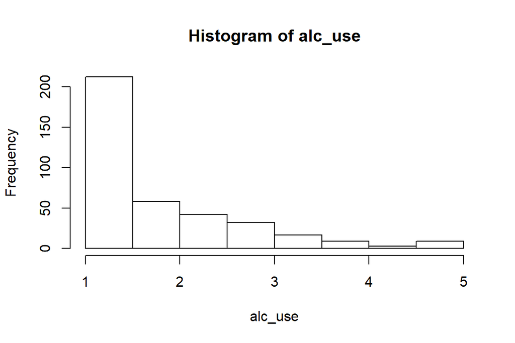

```r
# First let's get the variables.
alc_use<-a$alc_use
age<-a$age
studytime<-a$studytime
failures<-a$failures
freetime<-a$freetime
# ... then let's look at their distributions.
hist(alc_use)
```

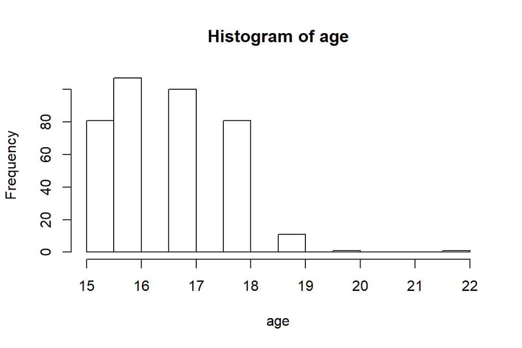

```r
hist(age)
```

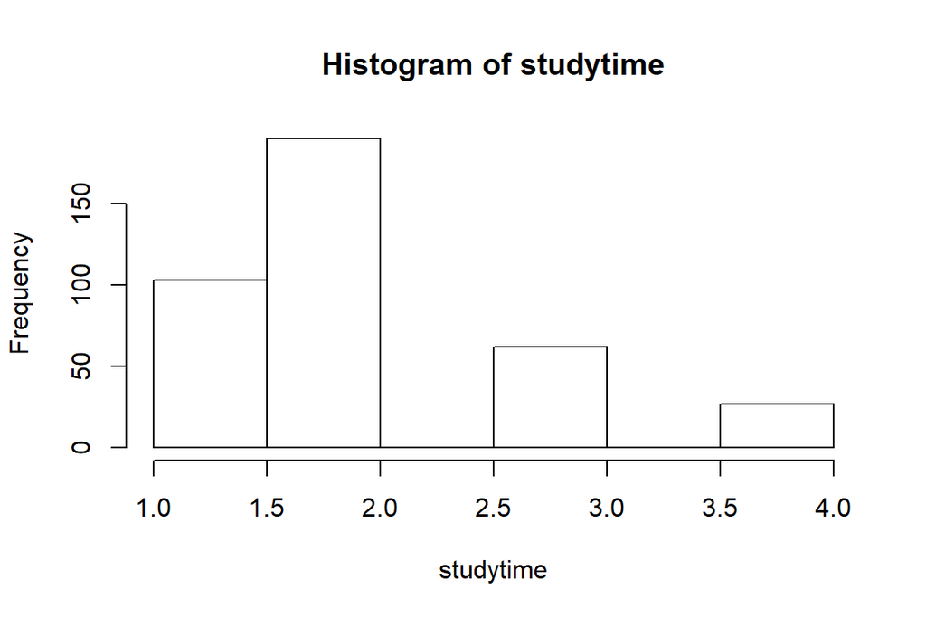

```r
hist(studytime)
```

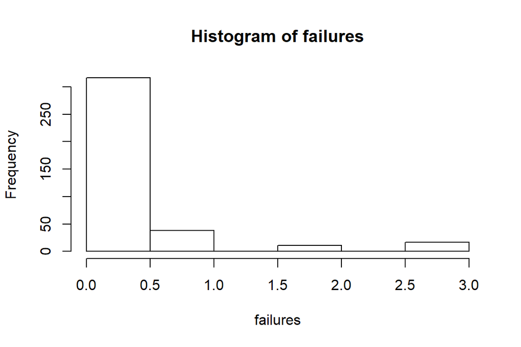

```r
hist(failures)
```

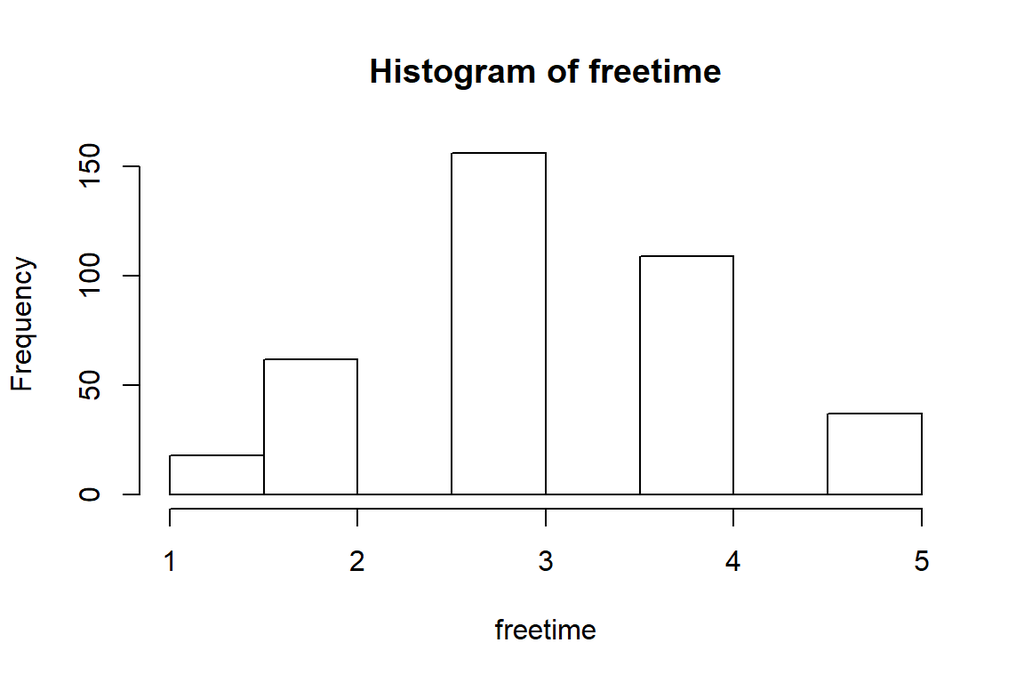

```r
hist(freetime)
```

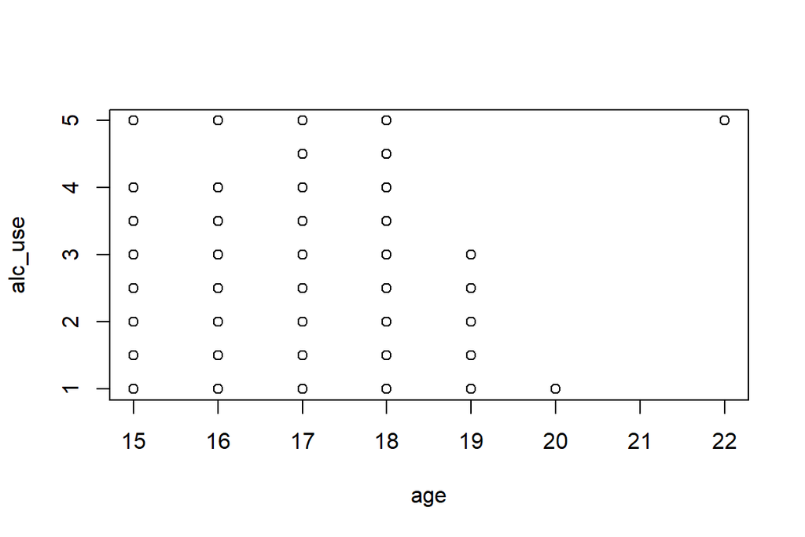

```r
# Then let's look at their relationships with alcohol consumption.
plot(age,alc_use)
```

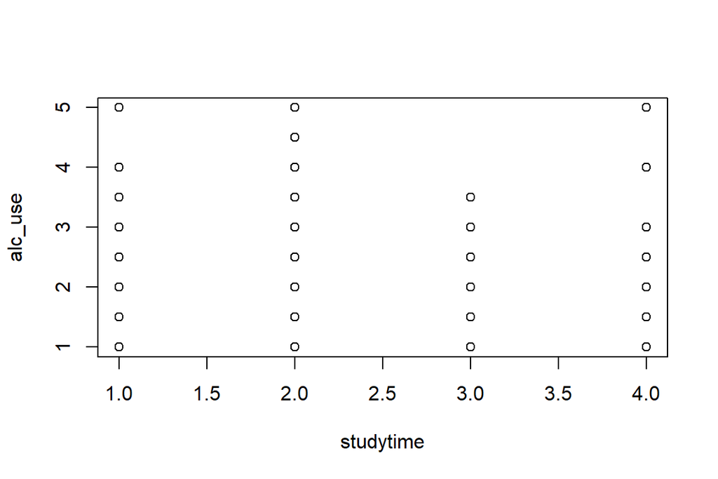

```r
plot(studytime, alc_use)
```

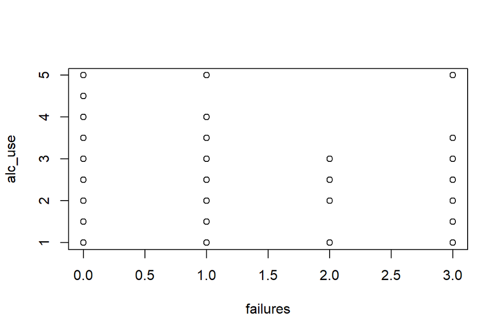

```r
plot(failures,alc_use)
```

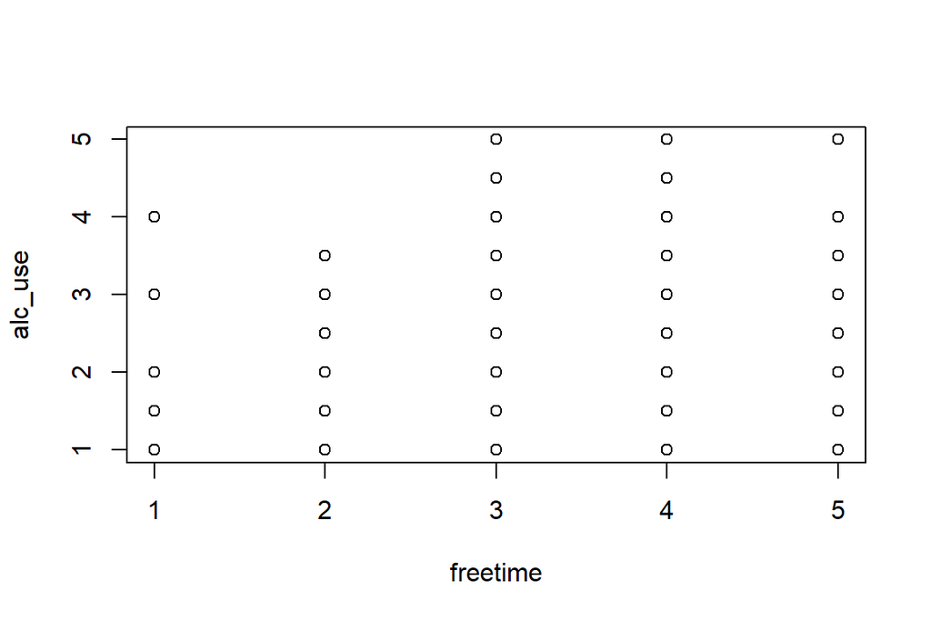

```r
plot(freetime,alc_use)
```

From the plots one can infer that age does not seem to have a clear relationship with drinking (if it were not about one outlier, it would seem that the older ones would drink less than the young). Studytime and failures also give mixed results. It seems that if there were a relationship it is not linear.For example in the case of past class failures, a mediocre levels (2) seems to cause less alcohol consumption. Only freetime seems to have a modest relationship - more freetime could modestly increase drinking. All in all the model I build does not seem to predict alcohol use too well.

## Exercise 5: Logistic regression

```r
high_use2<-ifelse(a$alc_use>2,1,0)
high_use2
```

```
##   [1] 0 0 1 0 0 0 0 0 0 0 0 0 0 0 0 0 0 0 1 0 0 0 0 1 0 0 0 1 0 1 1 0 0 0 0
##  [36] 0 0 0 0 0 0 1 0 0 0 0 1 0 0 0 1 0 1 1 1 0 0 0 0 0 1 1 0 1 1 0 1 0 0 1
##  [71] 0 0 1 0 1 1 0 0 0 0 0 0 0 0 0 1 1 0 0 0 1 0 0 1 0 0 0 0 0 0 0 1 0 0 0
## [106] 0 0 0 0 0 1 0 0 0 0 0 0 0 0 0 0 1 0 0 0 0 1 0 1 0 0 1 0 0 0 1 0 0 1 0
## [141] 0 0 0 0 0 1 0 0 0 0 0 0 0 1 1 1 1 0 0 0 1 1 0 1 0 1 1 0 0 0 1 0 0 0 0
## [176] 1 1 1 1 0 1 0 0 1 1 0 1 0 0 0 1 0 0 1 1 0 0 0 1 1 0 1 0 0 0 0 1 0 0 1
## [211] 0 0 1 0 1 0 0 1 1 1 0 0 0 0 1 0 0 0 0 1 0 0 0 0 1 0 0 1 0 0 1 1 1 0 0
## [246] 0 0 0 0 1 0 1 1 0 1 0 1 0 0 0 0 0 0 0 0 0 0 1 1 0 0 0 1 0 0 0 0 1 0 1
## [281] 1 0 0 1 1 0 0 0 0 0 0 0 0 0 1 0 0 0 0 1 0 0 0 0 0 0 0 0 0 0 0 1 1 0 0
## [316] 0 1 1 0 1 1 0 0 0 1 0 0 0 0 0 1 0 1 0 0 0 0 0 1 0 1 0 1 1 1 1 1 0 0 0
## [351] 0 0 0 0 0 0 1 0 0 0 1 1 0 0 0 0 1 0 1 1 0 0 0 1 0 0 0 0 0 0 1 1
```

```r
# Then the model...
fit<-glm(high_use2~age+studytime+failures+freetime,family = "binomial")
summary(fit)
```

```
##
## Call:
## glm(formula = high_use2 ~ age + studytime + failures + freetime,
##     family = "binomial")
##
## Deviance Residuals:
##     Min       1Q   Median       3Q      Max
## -1.7077  -0.8505  -0.6735   1.1927   2.2479
##
## Coefficients:
##             Estimate Std. Error z value Pr(>|z|)
## (Intercept)  -3.9034     1.7768  -2.197 0.028031 *
## age           0.1833     0.1026   1.786 0.074047 .
## studytime    -0.5374     0.1585  -3.392 0.000695 ***
## failures      0.2391     0.1555   1.538 0.124148
## freetime      0.2868     0.1221   2.348 0.018851 *
## ---
## Signif. codes:  0 '***' 0.001 '**' 0.01 '*' 0.05 '.' 0.1 ' ' 1
##
## (Dispersion parameter for binomial family taken to be 1)
##
##     Null deviance: 462.21  on 381  degrees of freedom
## Residual deviance: 431.16  on 377  degrees of freedom
## AIC: 441.16
##
## Number of Fisher Scoring iterations: 4
```

Studytime seems to be negatively and statistically significantly related heavy drinking. Freetime seems to be positively and statistically significantly related. Also age seems to be almoust statistically significant predictor of heavy drinking (positively related).

Now lets look at odds ratios.

```r
exp(cbind(OR=coef(fit),confint(fit)))
```

```
##                     OR        2.5 %    97.5 %
## (Intercept) 0.02017238 0.0005879718 0.6334497
## age         1.20119842 0.9842097937 1.4731056
## studytime   0.58424082 0.4242859239 0.7907465
## failures    1.27012769 0.9345449889 1.7265295
## freetime    1.33209361 1.0515432910 1.6989304
```

This means that one unit increase in studytime decreases the likehood of beeing a heavy drinker by almost 40 % (keeping all other variables constant). One unit increase in freetime increases the likehood of beeing a heavy drinker about one third (keeping all other variables constant).

So my hypothesis that freetime enables drinking can be confirmed (with caution). On the other hand studytime hypothesis cannot be confirmed. On the contrary, the more people study, the lower is their propability of beeing a heavy drinker. This indicates that education makes peoples’ driking habbits more civilized, not that it causes stress and makes heavy drinkers.

## Exercise 6: Predictive power of the model

```r
fit2<-glm(high_use2~studytime+freetime,family = "binomial")
summary(fit2)
```

```
##
## Call:
## glm(formula = high_use2 ~ studytime + freetime, family = "binomial")
##
## Deviance Residuals:
##     Min       1Q   Median       3Q      Max
## -1.2491  -0.8892  -0.6958   1.2330   2.1223
##
## Coefficients:
##             Estimate Std. Error z value Pr(>|z|)
## (Intercept)  -0.7463     0.5283  -1.413 0.157782
## studytime    -0.5714     0.1539  -3.712 0.000205 ***
## freetime      0.2969     0.1209   2.456 0.014039 *
## ---
## Signif. codes:  0 '***' 0.001 '**' 0.01 '*' 0.05 '.' 0.1 ' ' 1
##
## (Dispersion parameter for binomial family taken to be 1)
##
##     Null deviance: 462.21  on 381  degrees of freedom
## Residual deviance: 438.01  on 379  degrees of freedom
## AIC: 444.01
##
## Number of Fisher Scoring iterations: 4
```

Now lets explore the predictive power and accuracy of the model…

```r
a1<-data.frame(high_use2,studytime,freetime)
pred<-predict(fit2,newdata=a1,type="response")
pred=ifelse(pred>0.5,1,0)
table(pred,a1$high_use2)
```

```
##
## pred   0   1
##    0 260 103
##    1  10   9
```

```r
misCl<-mean(pred!=a1$high_use)
misCl
```

```
## [1] 0.2958115
```

```r
print(paste("Accuracy is",c(1-misCl)))
```

```
## [1] "Accuracy is 0.704188481675393"
```

Then lets compare it to quessing…

```r
table(high_use2)
```

```
## high_use2
##   0   1
## 270 112
```

If one would gues that all students were low-users, the accuracy would be 270/(270+112)=0.7068063. My model seems thus to have a very poor predictive power.

## Exercise 7: Validation of the model

10-fold cross-validation…

```r
library(boot)
cv.glm(a1,fit2,K=10)$delta
```

```
## [1] 0.1992458 0.1990271
```

## Exercise 8: Comparing different models

Comparing models with 10,8,6,4 and 2 independent variables.

```r
a$high_use2<-ifelse(a$alc_use>2,1,0)

fit10<-glm(high_use2~age+studytime+failures+freetime+Medu+Fedu+traveltime+goout+Dalc+Walc,data=a,family="binomial")
fit8<-glm(high_use2~age+studytime+failures+freetime+Medu+Fedu+traveltime+goout,data=a,family="binomial")

fit6<-glm(high_use2~age+studytime+failures+freetime+Medu+Fedu,data=a,family="binomial")

fit4<-glm(high_use2~age+studytime+failures+freetime,data=a,family="binomial")

fit2<-glm(high_use2~age+studytime,data=a,family="binomial")

# Then lets calculate training and testing errors.

er10<-cv.glm(a, fit10,K=10)$delta
er10
```

```
## [1] 3.897913e-21 3.730861e-21
```

```r
er8<-cv.glm(a, fit8,K=10)$delta
er8
```

```
## [1] 0.1777025 0.1771228
```

```r
er6<-cv.glm(a, fit6,K=10)$delta
er6
```

```
## [1] 0.1992263 0.1987955
```

```r
er4<-cv.glm(a, fit4,K=10)$delta
er4
```

```
## [1] 0.1960379 0.1958003
```

```r
er2<-cv.glm(a, fit2,K=10)$delta
er2
```

```
## [1] 0.1975151 0.1973777
```

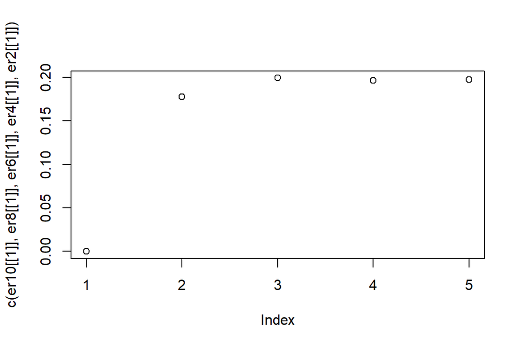

```r
# Training errors
plot(c(er10[[1]],er8[[1]], er6[[1]], er4[[1]], er2[[1]]))
```

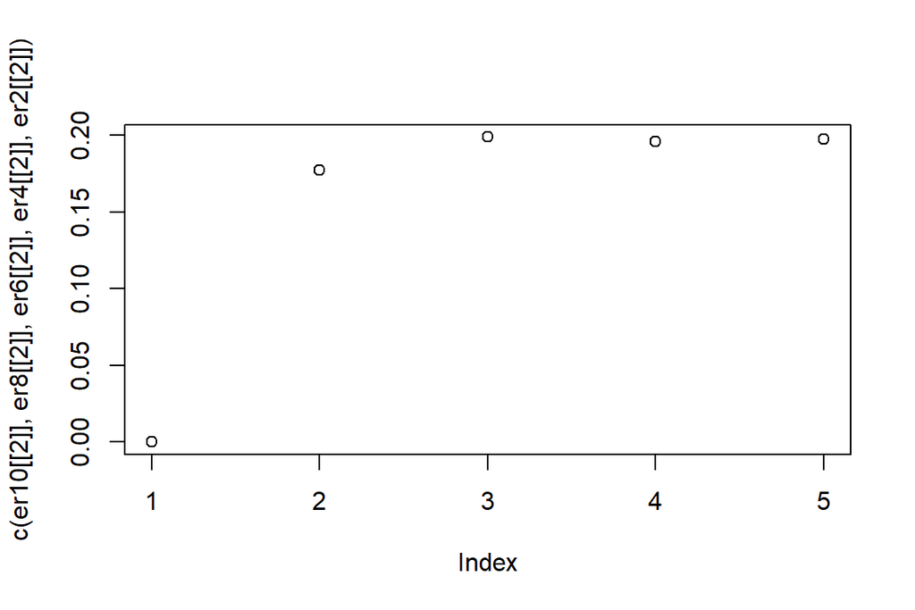

```r
# Testing errors
plot(c(er10[[2]],er8[[2]], er6[[2]], er4[[2]], er2[[2]]))
```

# Chapter 4: Clustering and classification

## Exercise 2:

First let’s load and explore the data

```r
library(MASS)
data(Boston)
str(Boston)
```

```
## 'data.frame':    506 obs. of  14 variables:
##  $ crim   : num  0.00632 0.02731 0.02729 0.03237 0.06905 ...
##  $ zn     : num  18 0 0 0 0 0 12.5 12.5 12.5 12.5 ...
##  $ indus  : num  2.31 7.07 7.07 2.18 2.18 2.18 7.87 7.87 7.87 7.87 ...
##  $ chas   : int  0 0 0 0 0 0 0 0 0 0 ...
##  $ nox    : num  0.538 0.469 0.469 0.458 0.458 0.458 0.524 0.524 0.524 0.524 ...
##  $ rm     : num  6.58 6.42 7.18 7 7.15 ...
##  $ age    : num  65.2 78.9 61.1 45.8 54.2 58.7 66.6 96.1 100 85.9 ...
##  $ dis    : num  4.09 4.97 4.97 6.06 6.06 ...
##  $ rad    : int  1 2 2 3 3 3 5 5 5 5 ...
##  $ tax    : num  296 242 242 222 222 222 311 311 311 311 ...
##  $ ptratio: num  15.3 17.8 17.8 18.7 18.7 18.7 15.2 15.2 15.2 15.2 ...
##  $ black  : num  397 397 393 395 397 ...
##  $ lstat  : num  4.98 9.14 4.03 2.94 5.33 ...
##  $ medv   : num  24 21.6 34.7 33.4 36.2 28.7 22.9 27.1 16.5 18.9 ...
```

```r
dim(Boston)
```

```
## [1] 506  14
```

The data includes 506 observations and 14 variables about towns, for example per capita crime rate and important variables related to the population and environment, for example proportion of non-retail business acres per town and average number of rooms per dwelling etc.